# MLforTimeSeriesForecasting code

## Machine Learning versus Statistical Models for Time Series Forecasting

Floyd Mayweather versus Muhammed Ali. The greatest of all time versus the immortal legend. Wouldn’t that be the best match-up imaginable? No. Believe it or not, but I have a better one for you: The all-rounder with unlimited potential versus the consistently performing classic. Machine learning versus statistical models! Which one is better in time series forecasting?

## The match

Before we dive into the comparison, let’s give our definition of statistical and machine learning models. We define a statistical model as a model that is interpretable based on its architecture and mathematical representation. Examples of these are exponential smoothing and autoregressive-moving-average (ARIMA) models. We define a machine learning model as a model that has a relatively complex architecture with a significant number of not easy interpretable parameters. Examples of these in time series forecasting are recurrent neural networks (RNN) including long short-term memory (LSTM) units or feedforward neural networks based on dilated causal convolutional layers.

Based on these definitions the statistical model should be able to give us insights the machine learning model does not. Furthermore, due to the difference in number of parameters we expect the statistical model to require significant less training time compared to the machine learning model. At the same time this does make the machine learning model more flexible and hopefully this makes it able to learn patterns that we are not able to model in the statistical model.

To see how both methods perform relative to each other, we look at a set of performance indicators that we will assess in the different sections of this use case. The following indicators were taken into account: Accuracy, learnability, explainability, modeling time, training time and data utility. They will be introduced throughout this case. The match will take place in the city of Chicago. The time series data used is a data set of hourly energy consumption recorded by ComEd, the largest electricity distributor in (northern) Illinois, USA. The data has a horizon of January 1st, 2011 till August 2nd, 2018. Below is a plot of the data.

```python
# Import libraries and functions
import datetime as dt
import pandas as pd
import matplotlib.pyplot as plt
%matplotlib inline


# Function that interpolates missing values by taking the mean of the surrounding values or alternatively taking one of
# the surrounding values
# data:   pd.DataFrame,   The data on which interpolation is done
def interpolate(data):
    full_date_range = pd.date_range(min(data.index), max(data.index), freq='H')
    hour = dt.timedelta(hours=1)
    for i in full_date_range:  # interpolate mean of values around missing value
        if i not in data.index:  # if there is a missing value take mean of 2 surrounding values
            if i - hour in data.index and i + hour in data.index:  # only if those 2 values exist
                data[i] = (data[i - hour] + data[i + hour]) / 2
            else:  # otherwise take the previous recorded value (we assume that data[0] exists)
                data[i] = data[i - hour]

    return data
```

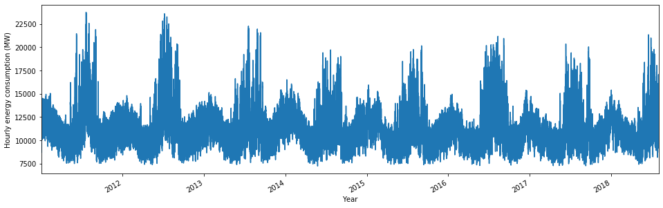

```python
# Read in the data and plot graph
pjm_data = pd.read_csv("Data/PJM_energy_usage_1999-2017.csv")
pjm_data.index = pd.to_datetime(pjm_data["Datetime"])
start, end = '2011-01-01 01:00:00', '2018-08-02 23:00:00'  # this is the date range of COMED
comed_data = pjm_data.loc[(pjm_data.index >= start) & (pjm_data.index <= end), 'COMED']
comed_data = comed_data.groupby(comed_data.index.to_period('H')).mean()  # take mean for multiple recordings (4 cases)
comed_data.index = comed_data.index.to_timestamp()  # set index back to datetime object
comed_data = comed_data.sort_index()  # sort the index
comed_data = interpolate(comed_data)  # interpolate missing values (11 cases)


comed_data.plot(figsize=(16.0, 5.0))
plt.rc('figure', figsize=(16.0, 5.0))  # make sure all future pots have the same figure size
plt.xlabel('Year')
plt.ylabel('Hourly energy consumption (MW)');
```

The goal will be to predict the next 24 hours of energy consumption. Accuracy will be measured by two error metrics. One is the symmetric mean average percentage error (sMAPE), which is easy to interpret. The other one is the mean absolute scaled error (MASE), which denotes the mean absolute error divided by the in-sample one-step naïve forecast and therefore shows the value of the predictive model relative to the naïve forecast.

## Round one: The competitors take the stage

In this round we will use February 2017 as our train data and the first week of March 2017 as test data. This means we will do 7 predictions of 24 hours, based on the data that is available at that point in time.

In one corner, we have the statistical model: a seasonal autoregressive-moving-average (SARIMA). This model is used since it gives us the possibility to model seasonality, while also providing the structure to model terms that deal with non-stationarity. Since there is a clear 24 hour per day season present, we use 24 as the periodicity of the season. To get the optimal order of the different model terms, we use a function that is built to identify the most optimal parameters. Besides that we also add the value of the week before in our model, since there is also a weekday season present. After obtaining the right orders, we optimize the parameters and do our predictions. Below is a plot of the results.

```python
# Import libraries and functions
import numpy as np
from pmdarima import auto_arima  # we use auto_arima from pmdarima to determine optimal model orders
from statsmodels.tsa.statespace import sarimax  # we use sarimax from statsmodels to model the SARIMA model

# Initialization
hour = dt.timedelta(hours=1)  # this hour will be used to make intervals closed, only global variable

# Function that returns the ranges that will be used for training and prediction
# start:        str,                The start date that the data will have
# train_period: pd.DatetimeIndex,   The period used for training
# pred_period:  pd.DatetimeIndex,   The period used for a single prediction
# pred_times:   int,                The number of times we will predict
def get_ranges(start, train_period, pred_period, pred_times):
    start_pred = start + train_period  # when prediction starts
    end_pred = start_pred + pred_times * pred_period  # when prediction ends
    train_range = pd.date_range(start, start_pred - hour, freq='H')  # range of data for training
    pred_range = pd.date_range(start_pred, end_pred - hour, freq='H')  # range of data for prediction

    return train_range, pred_range


# Function that returns the X_data used as independent variables and Y_data used as dependent variables
# train_range:  pd.DatetimeIndex    The range that  will be used for training
# pred_range:   pd.DatetimeIndex    The range that will be used for prediction
# Y_data:       pd.Series,          The dependent variable (that will also be used as independent variable)
# X_data:       pd.DataFrame,       The independent variables
# lags_endo:    [int],              The different lags of the dependent variable that will be used as independent var.
# lags_exo:     [int],              The different lags of the independent variable
# week_dummies: bool,               If there should be dummies added for the day of the week
def get_data(train_range, pred_range, Y_data, X_data=None, lags_endo=[], lags_exo=[], week_dummies=False):
    total_range = train_range.append(pred_range)  # all data that will be used
    Y_total = Y_data[total_range]
    X_total = pd.DataFrame(index=Y_total.index)  # create data frame for independent variables

    for i in lags_endo:
        X_total['Y-' + str(i)] = Y_data.shift(i)[total_range]
    for i in lags_exo:
        X_total['X-' + str(i)] = X_data.shift(i)[total_range]
    if week_dummies:  # add weekly dummies
        for weekday in X_total.index.weekday.unique().sort_values()[1:]:
            X_total[str(weekday)] = np.zeros(X_total.shape[0])
            X_total.loc[X_total.index.weekday == weekday, str(weekday)] = 1

    return Y_total, X_total


# Function that predicts, prints error metrics and plots the train data, test data and prediction
# Y_data:           pd.Series,          The dependent variable data in a pandas series object
# fit_model:        .Model,             A fitted model, can be a Keras model or a Statsmodels model
# start:            str,                The start date that the data will have
# train_period:     pd.DatetimeIndex,   The period used for training
# pred_period:      pd.DatetimeIndex,   The period used for a single prediction
# pred_times:       int,                The number of times we will predict
# model_type:       str,                A string that specifies the type of model (NAIVE, SARIMAX or KERAS)
# X_data:           pd.DataFrame,       The data used as dependent variables
# X_or:             pd.DataFrame,       The data used as dependent variables in its original form
# Y_data_scaled:    pd.Series,          The dependent variable data in a pandas series object scaled
# scaler:           sklearn.Scaler,     A sklearn scaler with which the Y_data was scaled
# orders:           tuple,              A tuple including the orders in the case of a SARIMAX model
# seasonal_orders:  tuple,              A tuple including the seasonal orders in the case of a SARIMAX model
# plot_results:     bool,               Makes a plot of the results if True
# print_metrics:    bool,               Prints the error metrics if True
def predict(Y_data, fit_model, start, train_period, pred_period, pred_times, model_type='NAIVE', X_data=None, X_or=None,
            Y_data_scaled=None, scaler=None, orders=(), seasonal_orders=(), plot_results=True, print_metrics=True):
    train_range, pred_range = get_ranges(start, train_period, pred_period, pred_times)
    Y_pred = pd.Series(index=pred_range)  # this will contain all predictions together
    hour = dt.timedelta(hours=1)  # this is used to make open intervals closed
    if plot_results:
        fig, (ax1, ax2) = plt.subplots(1, 2, sharey=False)
        Y_data[train_range].plot(ax=ax1)  # plot the graph with training data
        Y_data[pred_range].plot(ax=ax2)  # plot the graph with training data
        ax1.set_title('Training set')
        ax2.set_title('Test set')
        ax1.set_ylabel('Hourly energy consumption (MW)')
        if X_or is not None:
            ax3 = ax1.twinx()
            ax2.yaxis.tick_right()
            ax2.set_yticks(ax2.get_yticks()[1:])
            X_or[train_range].plot(ax=ax3, color='C3')
            ax3.legend(['Hourly temperature(\'F)'], loc='upper right')
        plt.subplots_adjust(wspace=0.1, hspace=0);

    for i in range(pred_times):  # we will predict multiple time using all available data at that time
        end_current_range = start + train_period + pred_period * i  # end of current period
        end_next_range = end_current_range + pred_period  # end of future period
        current_range = pd.date_range(start, end_current_range - hour, freq='H')  # current training period
        next_range = pd.date_range(end_current_range, end_next_range - hour, freq='H')  # current pred. period
        if model_type == 'SARIMAX':
            if X_data is not None:
                X_current, X_pred = X_data.loc[current_range, :], X_data.loc[next_range, :]
            else:
                X_current, X_pred = None, None
            Y_current = Y_data[current_range]  # create SARIMAX object with the data for the current period
            expand_model = sarimax.SARIMAX(Y_current, exog=X_current, order=orders, seasonal_order=seasonal_orders)
            expand_fit_model = expand_model.filter(fit_model.params)  # add trained model's parameters to model
            prediction = expand_fit_model.predict(end_current_range, end_next_range - hour, exog=X_pred)  # predict
        elif model_type == 'KERAS':
            if X_data is not None:
                Y_current = Y_data_scaled[current_range].values.reshape(-1, 1)
                X_current = X_data.loc[current_range, :].values
                train_data = np.concatenate([Y_current, X_current], axis=1)
            else:
                train_data = Y_data_scaled[current_range].values.reshape(-1, 1)
            prediction = fit_model.predict(train_data.reshape((1, train_data.shape[0], -1))).reshape(-1)
            prediction = scaler.inverse_transform(prediction.reshape(-1, 1)).reshape(-1)  # denormalize
        else:  # model_type == 'NAIVE'
            prediction = Y_current[-next_range.shape[0]:]  # just use the previous values
        Y_pred[next_range] = prediction  # save prediction
        if plot_results:
            Y_pred[next_range].plot(ax=ax2, color='C1', label='test')

    if plot_results:
        handles, labels = ax2.get_legend_handles_labels()
        ax2.legend(handles=handles[-1:], labels=['Predictions 1-7'], loc='upper right')

    if print_metrics:
        Y_test, Y_train = Y_data[pred_range], Y_data[train_range]
        print("The error metrics for these predictions are the following: {0:.2f}%".format(sMAPE(Y_test, Y_pred))
              + " (sMAPE) and {0:.2f} (MASE)".format(MASE(Y_train, Y_test, Y_pred, 24)))


# Function that returns the symmetric mean absolute percentage error
# Y_test:   pd.Series,  The test data
# Y_pred:   pd.Series,  The prediction data
def sMAPE(Y_test, Y_pred):
    return 2 / Y_test.shape[0] * sum(abs(Y_test - Y_pred) / (abs(Y_test) + abs(Y_pred))) * 100


# Function that returns the mean absolute scaled error
# Y_train:  pd.Series,  The train data
# Y_test:   pd.Series,  The test data
# Y_pred:   pd.Series,  The prediction data
# freq_time:    The time between successive observations for the data frequency
def MASE(Y_train, Y_test, Y_pred, freq_time):
    return 1 / Y_test.shape[0] * sum(abs(Y_test - Y_pred)) / \
        (1 / (Y_train.shape[0] - freq_time) * sum(abs(Y_train[freq_time+1:] - Y_train.shift(freq_time)[freq_time+1:])))
```

```python
# Define the training and prediction dates and periods
start_year, start_month, start_day = 2017, 2, 1  # start date
start = dt.datetime(start_year, start_month, start_day)
train_period = dt.timedelta(weeks=4)  # period we select as training data
forecast_horizon = 24  # how far we predict ahead
pred_period = dt.timedelta(hours=forecast_horizon)  # the prediction period is the forecast horizon in hours
pred_times = 7  # number of times we will predict

# Get train and prediction ranges and use them to get the data that will be used
train_range, pred_range = get_ranges(start, train_period, pred_period, pred_times)
Y_total, X_total = get_data(train_range, pred_range, comed_data, lags_endo=[7 * 24])  # X_total contains the new lag
train_range_adjusted = (train_range + dt.timedelta(weeks=1))[:-24 * 7]  # adjust training range to remove first week
```